# Financial Impact of Integrated Specialty Pharmacy Efforts to Avoid Oral Oncolytic Waste

# 1 Study details

## 1.1 Study title

Oncology Waste Avoidance

## 1.2 Background

A growing number of oral oncolytic agents have been developed in recent decades. Though newer agents provide more options for patients to treat cancer using self-administered therapy, they may pose burdens on patients, including high cost and side effects. Patients receiving oncolytic therapy require frequent follow-up with scans, laboratory tests, and clinic visits, for healthcare providers to monitor drug safety and disease progression. Treatment plans are often adjusted at the time of planned follow-up, leading to changes in medications or dosing. As a result of these changes, medications are often wasted, which poses a high economic burden on healthcare systems.

## 1.3 Objectives

The purpose of this study was to describe an integrated health-system specialty pharmacy’s efforts to reduce medication waste for patients prescribed oral oncolytic medication.

## 1.4 Methods

Retrospective review of patients filling oral oncolytic medications prescribed by a Vanderbilt University Medical Center (VUMC) provider with medication dispensed by the Vanderbilt Specialty Pharmacy (VSP) between January 1, 2020 and January 31, 2021.

Data was gathered from the electronic health record (EPIC/EStar), VSP dispense software (EnterpriseRx), and the specialty pharmacy patient management software (Atlas).

Specialty pharmacy staff received a system-generated renewal request for oral oncolytic medications when the final prescription refill was dispensed, prompting the pharmacist to review the patient’s medical record for continued therapy appropriateness and to request a new prescription. With access to the electronic health record, the pharmacist would review upcoming appointments and clinic notes. If the patient had a sufficient supply on hand to last until after an upcoming follow-up, the pharmacist postponed the renewal until after the scheduled follow-up.

### 1.4.1 Inclusion criteria

- Patients were included if the refill renewal request was postponed after review of the amount of medication on hand and presence of an upcoming follow-up.
- And if patients had a clinic visit between 01/01/20 to 01/31/21.

### 1.4.2 Exclusion Criteria

- Treatment regimens consisting of multiple strengths of the same medication to reach the prescribed dose were only included as a single refill renewal request postponement. (i.e., If the patient had prescriptions for temozolomide 100mg and temozolomide 5mg to reach a total dose of 310mg and the specialty pharmacist postponed the refill renewal request for both prescriptions because the patient had sufficient quantity to make it through until after an upcoming follow-up, this would be counted as a single refill renewal request postponement even though 2 refill renewal requests were postponed.)
- Postponed renewal requests were excluded from analysis if:
  - They were part of a multi-strength regimen (explained above) labeled as duplicate
  - Patient did not complete clinical follow-up
  - Patient transferred care before clinical follow-up
  - Medication was discontinued or the patient died before clinical follow-up

## 1.5 Outcomes of interest

### 1.5.2 Determining Outcomes

**Waste Avoidance**

- No Waste Avoidance
  - Medication continued as previously prescribed after follow-up
- Medication Waste Avoidance
  - Medication was discontinued, changed or held after follow-up
  - Multi-strength drug regimens were counted as 1 refill postponement
- Financial Waste Avoidance
  - Medication discontinuation, change or hold would have resulted in
    - The patient having medication on hand that could not be used
    - The patient having excess quantity of medication on hand

**Assigning Cost**

- Medication Discontinuation or Change
  - Quantity of medication that would have been refilled x AWP per unit
- Dose Change or Medication Hold
  - Quantity of medication, if refilled, that could not be used x AWP per unit
  - Quantity of medication, if refilled, that would have been in excess x AWP per unit
- Excluded from the financial analysis
  - Medication could have been used to make the new dose
  - Medication could have been used if restarted after a medication hold

# 2 Descriptive Statistics

## 2.1 Patient Characteristics

The sample size indicates the number of patients.

| Patient Characteristics. | Patient Characteristics. *N=139* |
| --- | --- |
| Age | 50 64 72 |
| Gender |  |
| Female | 0.56 (78) |
| Male | 0.44 (61) |
| Ethnic group |  |
| Not Hispanic, Latino/a, or Spanish origin | 0.91 (126) |
| Other Hispanic, Latino/a, or Spanish origin | 0.01 ( 2) |
| Unknown | 0.02 ( 3) |
| Decline to Answer | 0.01 ( 1) |
| NA | 0.05 ( 7) |
| Patient race |  |
| White | 0.86 (119) |
| Black or African American | 0.04 ( 6) |
| Other Asian | 0.02 ( 3) |
| Unknown | 0.01 ( 2) |
| Other | 0.03 ( 4) |
| NA | 0.04 ( 5) |
| Patient status |  |
| Alive | 0.86 (119) |
| Deceased | 0.14 ( 20) |

*a* *b* *c* represent the lower quartile *a*, the median *b*, and the upper quartile *c* for continuous variables. Numbers after proportions are frequencies.

## 2.2 Outcome of follow-up

The sample size indicates the number of renewal requests.

| Outcome of follow-up. | Outcome of follow-up. *N=167* |
| --- | --- |
| Reason for medication postponement |  |
| Clinic visit | 0.88 (147) |
| Labs needed | 0.05 ( 8) |
| Imaging needed | 0.01 ( 1) |
| Other | 0.07 ( 11) |
| Outcome of follow-up |  |
| No change to postponed medication | 0.02 ( 3) |
| Medication change | 0.06 (10) |
| Dosing change | 0.31 (52) |
| Medication discontinued | 0.56 (94) |
| Medication held | 0.05 ( 8) |
| Formulaton change | 0.00 ( 0) |

Numbers after proportions are frequencies.

## 2.3 Medication holds

The sample size indicates the number of renewal requests with a medication hold as an outcome.

| Medication hold outcomes. | Medication hold outcomes. *N=8* |
| --- | --- |
| Hold outcome |  |
| Patient restarted original medication | 0.25 (2) |
| Dose change | 0.25 (2) |
| Discontinuation | 0.50 (4) |

Numbers after proportions are frequencies.

## 2.4 Cost avoidance analysis

Cost savings were calculated by first filtering out all rows that are not classified as cost savings as defined in the previous section. The AWP/unit (cost per pill) was obtained for each medication based on drug name, strength and if the brand or generic formulation had been dispensed on the previous fill. To calculate the potential cost avoidance the AWP/unit was multiplied by the number of units that would have been wasted if the medication had been refilled prior to the patients upcoming follow-up.

### 2.4.1 Cost avoidance per fill

The sample size indicates the number of fills.

- The patients with a medication hold for their outcome of follow-up were reclassified to discontinuation or dose change, according to final outcome of the medication hold.

| Cost savings per fill by outcome in dollars. | Cost savings per fill by outcome in dollars. Dosing change *N=59* | Cost savings per fill by outcome in dollars. Medication change *N=12* | Cost savings per fill by outcome in dollars. Medication discontinued *N=104* | Cost savings per fill by outcome in dollars. Combined *N=175* |
| --- | --- | --- | --- | --- |
| Cost avoidance per fill | 366 2820 8477 | 3957 10038 16768 | 986 1951 5295 | 986 2417 8215 |

*a* *b* *c* represent the lower quartile *a*, the median *b*, and the upper quartile *c* for continuous variables.

### 2.4.2 By Outcome

Parentheses indicate column percentages

Table 2.1: Cost savings by outcome

| Outcome of Follow-up | Brand Cost savings | Brand n | Generic Cost savings | Generic n | Total Cost savings | Total n |
| --- | --- | --- | --- | --- | --- | --- |
| Dosing change | $147,432 (22.6%) | 16 | $146,641 (46.5%) | 42 | $294,073 (30.4%) | 58 |
| Medication change | $94,790 (14.5%) | 9 | $18,245 (5.8%) | 3 | $113,035 (11.7%) | 12 |
| Medication discontinued | $344,060 (52.7%) | 36 | $145,784 (46.2%) | 64 | $489,843 (50.6%) | 100 |
| Medication held | $66,259 (10.2%) | 3 | $4,612 (1.5%) | 2 | $70,871 (7.3%) | 5 |
| Total | $652,540.41 | 64 | $315,281.33 | 111 | $967,821.74 | 175 |

# 3 Poster Data

## 3.1 Figures

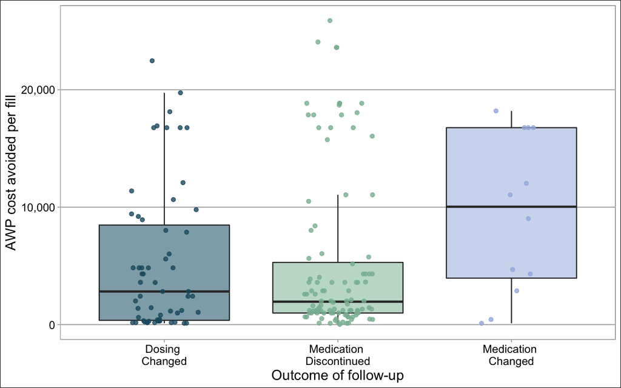

## 3.2 Medication Table

### 3.2.1 Sorted by total cost savings

|  | Medication | Fills | Total Cost Savings | Mean (SD) Cost Savings per Fill | IQR Cost Savings per Fill |
| --- | --- | --- | --- | --- | --- |
| 1 | TEMOZOLOMIDE | 66 | $249,708 | $3,783 ($3,960) | $2,878 ($1,439 - $4,316) |
| 2 | PALBOCICLIB | 11 | $173,274 | $15,752 ($3,371) | $16,768 ($16,768 - $16,768) |
| 3 | EVEROLIMUS | 5 | $84,816 | $16,963 ($4,215) | $18,848 ($18,848 - $18,848) |
| 4 | TRIFLURIDINE-TIPIRACIL | 5 | $69,186 | $13,837 ($7,244) | $12,032 ($9,024 - $18,049) |
| 5 | OLAPARIB | 4 | $62,504 | $15,626 ($4,465) | $17,858 ($15,626 - $17,858) |
| 6 | REGORAFENIB | 2 | $47,198 | $23,599 ($0) | $23,599 ($23,599 - $23,599) |
| 7 | ABIRATERONE ACETATE | 5 | $45,916 | $9,183 ($4,364) | $11,051 ($11,051 - $11,051) |
| 8 | BINIMETINIB | 3 | $34,117 | $11,372 ($4,009) | $10,498 ($9,185 - $13,122) |
| 9 | ENCORAFENIB | 3 | $32,098 | $10,699 ($4,633) | $8,024 ($8,024 - $12,037) |
| 10 | CAPECITABINE | 35 | $27,871 | $796 ($401) | $986 ($564 - $986) |

[output cut: 15 more lines]

### 3.2.2 Sorted by mean cost savings per fill

|  | Medication | Fills | Total Cost Savings | Mean (SD) Cost Savings per Fill | IQR Cost Savings per Fill |
| --- | --- | --- | --- | --- | --- |
| 1 | TUCATINIB | 1 | $25,891 | $25,891 (NA) | $25,891 ($25,891 - $25,891) |
| 2 | REGORAFENIB | 2 | $47,198 | $23,599 ($0) | $23,599 ($23,599 - $23,599) |
| 3 | ALPELISIB | 1 | $22,467 | $22,467 (NA) | $22,467 ($22,467 - $22,467) |
| 4 | RUXOLITINIB PHOSPHATE | 1 | $18,692 | $18,692 (NA) | $18,692 ($18,692 - $18,692) |
| 5 | RIBOCICLIB SUCCINATE | 1 | $18,195 | $18,195 (NA) | $18,195 ($18,195 - $18,195) |
| 6 | EVEROLIMUS | 5 | $84,816 | $16,963 ($4,215) | $18,848 ($18,848 - $18,848) |
| 7 | PALBOCICLIB | 11 | $173,274 | $15,752 ($3,371) | $16,768 ($16,768 - $16,768) |
| 8 | OLAPARIB | 4 | $62,504 | $15,626 ($4,465) | $17,858 ($15,626 - $17,858) |
| 9 | TRIFLURIDINE-TIPIRACIL | 5 | $69,186 | $13,837 ($7,244) | $12,032 ($9,024 - $18,049) |
| 10 | BINIMETINIB | 3 | $34,117 | $11,372 ($4,009) | $10,498 ($9,185 - $13,122) |

[output cut: 15 more lines]